# SI_618_Day_04_Stats_and_Visualization_Inclass

### **SI 618: Data Manipulation and Analysis** 🎓

#### **04 - Visualization & Univariate Statistics** 📊

👤 *Instructor: Dr. Chris Teplovs*  
🏫 *School of Information, University of Michigan*  
© 2024. *This notebook may not be shared outside the course without permission.*

## 📌 **Overview of Today** 🗒️

📢 **Announcements**  
❓ **Comments/Questions/Concerns**  
🔄 **Review of Last Week**: Pivoting, Aggregation & Grouping  
📊 **Today's Topics**: Univariate Statistics & Visualization

```python
import pandas as pd
import numpy as np
```

## 📌 **A Quick Note About Markdown Cells** 📝

We encourage you to use **Markdown cells** to add text to your notebooks. For more information, check out this [Markdown Guide](https://jupyter-notebook.readthedocs.io/en/stable/examples/Notebook/Working%20With%20Markdown%20Cells.html).  
💡 *Tip: You can examine any existing Markdown block by simply clicking on it!*

## 📌 **Visualization and Univariate Statistics** 📊

Let’s explore the relationship between **X** and **Y** for the following dataset:  
🔗 [Anscombe's Quartet - Data](https://en.wikipedia.org/wiki/Anscombe%27s_quartet#Data)

Take a moment to think about how you would visualize this relationship between **X** and **Y**.  
Do you see a nice linear relationship? 🤔

🔗 [Check out the full dataset here](https://en.wikipedia.org/wiki/Anscombe%27s_quartet#Data)

A nice linear relationship, right?

# 🌟 Anscombe's Quartet

[figure not shown]

([https://en.wikipedia.org/wiki/Anscombe's_quartet](https://en.wikipedia.org/wiki/Anscombe%27s_quartet))

## 📌 Matplotlib, the basis for visualization in python

## 🌟 **Matplotlib Resources** 🌐

Here are some useful links to help you get started with **Matplotlib**:

- 🔗 **Matplotlib Home Page**: [matplotlib.org](https://matplotlib.org/index.html)
- 🖼️ **Gallery of Examples**: [Explore the Matplotlib Gallery](https://matplotlib.org/gallery/index.html)
- 📊 **Sample Plots**: [Get Started with Sample Plots](https://matplotlib.org/tutorials/introductory/sample_plots.html)
- 📚 **Pyplot Tutorial**: [Learn More with the Pyplot Tutorial](https://matplotlib.org/users/pyplot_tutorial.html)

`matplotlib.pyplot` is a **collection of command-style functions** that make **Matplotlib** work like **MATLAB** 🧑‍🔬. Each `pyplot` function applies a specific change to a figure:

- 🖼️ **Creates a figure** to hold your plots.
- 🗺️ **Sets up a plotting area** within the figure.
- 📊 **Plots some data**, such as lines or scatter points.
- 🎨 **Decorates the plot** with labels, titles, and other features to enhance its readability and appearance.

✍️ **Remember**: With `pyplot`, you can sequentially build and customize your figures, much like constructing visualizations piece by piece.

## 📌 **Understanding `matplotlib.pyplot`** 🎨

`matplotlib.pyplot` is a **collection of functions** that make **Matplotlib** work in a way similar to **MATLAB** 🧑‍🔬. This can be helpful if you're familiar with MATLAB’s approach, but if not, don’t worry—it’s all about creating and customizing plots easily!

Here’s how it works:

- 📐 **Each function** changes or updates a figure. Let's break it down step-by-step:
  - 🖼️ **Create a figure** to hold your plot.
  - 🗺️ **Set up a plotting area** within the figure.
  - 📊 **Plot some data**—like drawing lines or scatter points in the plotting area.
  - 🎨 **Decorate your plot** with labels, titles, and other helpful information.

✍️ **Important**: States (like figure and plot configurations) are preserved across function calls, meaning what you set in one step remains until changed.

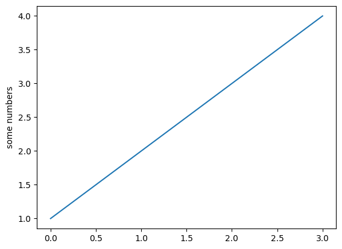

```python
import matplotlib.pyplot as plt
plt.plot([1, 2, 3, 4])
plt.ylabel('some numbers')
plt.show()
```

To specify **x- and y-values** for your plot, you can use the following approach:

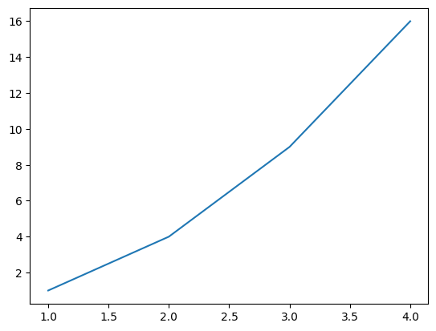

```python
plt.plot([1, 2, 3, 4], [1, 4, 9, 16])
```

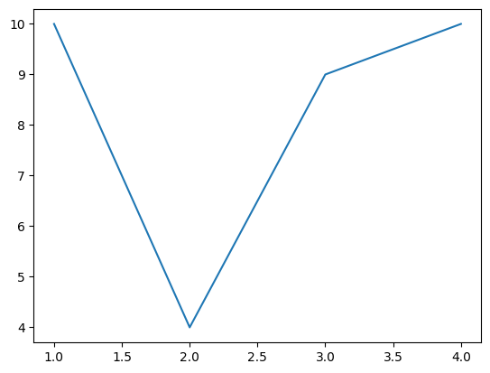

```python
import matplotlib.pyplot as plt
plt.plot([1,2,3,4], [10,4,9,10])
plt.show()
```

To specify **x- and y-values** for your plot, you can use the following approach:

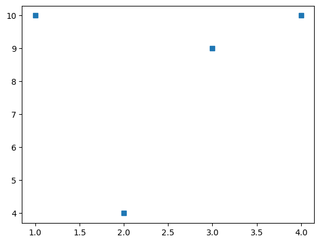

```python
import matplotlib.pyplot as plt
plt.plot([1,2,3,4], [10,4,9,10], 's')
plt.show()
```

We can explicitly set the bounds for the axes:

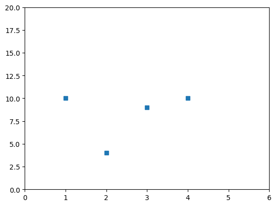

```python
import matplotlib.pyplot as plt
plt.plot([1,2,3,4], [10,4,9,10], 's')
plt.axis([0, 6, 0, 20])
plt.show()
```

Let's generate some data to play with:

```python
import numpy as np
import matplotlib.pyplot as plt

# evenly sampled time at 200ms intervals
t = np.arange(0., 5.2, 0.2)
t
```

```
array([0. , 0.2, 0.4, 0.6, 0.8, 1. , 1.2, 1.4, 1.6, 1.8, 2. , 2.2, 2.4,
       2.6, 2.8, 3. , 3.2, 3.4, 3.6, 3.8, 4. , 4.2, 4.4, 4.6, 4.8, 5. ])
```

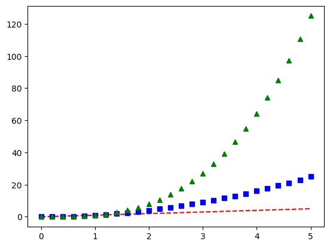

```python
# red dashes, blue squares and green triangles
plt.plot(t, t, 'r--', t, t**2, 'bs', t, t**3, 'g^')
plt.show()
```

```python
# listing of all marker types
markers = {'.': 'point', ',': 'pixel', 'o': 'circle',
    'v': 'triangle_down', '^': 'triangle_up', '<': 'triangle_left', '>': 'triangle_right',
    '1': 'tri_down', '2': 'tri_up', '3': 'tri_left', '4': 'tri_right', '8': 'octagon',
    's': 'square', 'p': 'pentagon', '*': 'star', 'h': 'hexagon1', 'H': 'hexagon2', '+': 'plus',
    'x': 'x', 'D': 'diamond', 'd': 'thin_diamond', '|': 'vline', '_': 'hline',
    'P': 'plus_filled', 'X': 'x_filled', 0:
    'tickleft', 1: 'tickright', 2: 'tickup', 3: 'tickdown',
    4: 'caretleft', 5: 'caretright', 6: 'caretup', 7: 'caretdown',
    8: 'caretleftbase', 9: 'caretrightbase', 10: 'caretupbase', 11: 'caretdownbase',
    'None': 'nothing', None: 'nothing', ' ': 'nothing', '': 'nothing'}
print(markers)
```

[output not shown]

For more details on how to customize your plots, you can refer to the following resources:

- 🔗 [Matplotlib Markers API](https://matplotlib.org/3.0.3/api/markers_api.html#module-matplotlib.markers): This guide will help you choose different marker styles for your data points, such as circles, squares, or triangles.
- 🔗 [Matplotlib Line2D Documentation](https://matplotlib.org/api/_as_gen/matplotlib.lines.Line2D.html#matplotlib.lines.Line2D): This resource provides detailed information on how to customize lines, including color, style, and more advanced properties.

Feel free to explore these links to enhance your plotting skills! 🎨

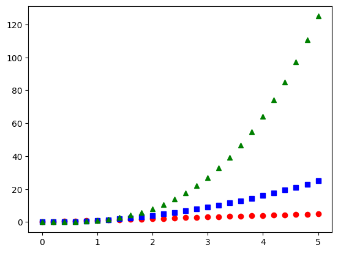

```python
plt.plot(t, t, marker='o', linestyle='', color='r')
plt.plot(t, t**2, marker='s', linestyle='', color='b')
plt.plot(t, t**3, marker='^', linestyle='', color='g')
plt.show()
```

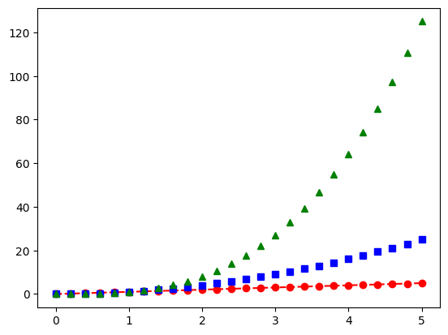

```python
plt.plot(t, t, marker='o', linestyle='--', color='r')
plt.plot(t, t**2, marker='s', linestyle='', color='b')
plt.plot(t, t**3, marker='^', linestyle='', color='g')
plt.show()
```

## 📌 Multiple plots

```python
def f(t):
    return np.exp(-t) * np.cos(2*np.pi*t)


t1 = np.arange(0.0, 5.1, 0.1)
t2 = np.arange(0.0, 5.02, 0.02)
```

```python
t1
```

```
array([0. , 0.1, 0.2, 0.3, 0.4, 0.5, 0.6, 0.7, 0.8, 0.9, 1. , 1.1, 1.2,
       1.3, 1.4, 1.5, 1.6, 1.7, 1.8, 1.9, 2. , 2.1, 2.2, 2.3, 2.4, 2.5,
       2.6, 2.7, 2.8, 2.9, 3. , 3.1, 3.2, 3.3, 3.4, 3.5, 3.6, 3.7, 3.8,
       3.9, 4. , 4.1, 4.2, 4.3, 4.4, 4.5, 4.6, 4.7, 4.8, 4.9, 5. ])
```

```python
t2
```

```
array([0.  , 0.02, 0.04, 0.06, 0.08, 0.1 , 0.12, 0.14, 0.16, 0.18, 0.2 ,
       0.22, 0.24, 0.26, 0.28, 0.3 , 0.32, 0.34, 0.36, 0.38, 0.4 , 0.42,
       0.44, 0.46, 0.48, 0.5 , 0.52, 0.54, 0.56, 0.58, 0.6 , 0.62, 0.64,
       0.66, 0.68, 0.7 , 0.72, 0.74, 0.76, 0.78, 0.8 , 0.82, 0.84, 0.86,
       0.88, 0.9 , 0.92, 0.94, 0.96, 0.98, 1.  , 1.02, 1.04, 1.06, 1.08,
       1.1 , 1.12, 1.14, 1.16, 1.18, 1.2 , 1.22, 1.24, 1.26, 1.28, 1.3 ,
       1.32, 1.34, 1.36, 1.38, 1.4 , 1.42, 1.44, 1.46, 1.48, 1.5 , 1.52,
       1.54, 1.56, 1.58, 1.6 , 1.62, 1.64, 1.66, 1.68, 1.7 , 1.72, 1.74,
       1.76, 1.78, 1.8 , 1.82, 1.84, 1.86, 1.88, 1.9 , 1.92, 1.94, 1.96,
       1.98, 2.  , 2.02, 2.04, 2.06, 2.08, 2.1 , 2.12, 2.14, 2.16, 2.18,
       2.2 , 2.22, 2.24, 2.26, 2.28, 2.3 , 2.32, 2.34, 2.36, 2.38, 2.4 ,
       2.42, 2.44, 2.46, 2.48, 2.5 , 2.52, 2.54, 2.56, 2.58, 2.6 , 2.62,
       2.64, 2.66, 2.68, 2.7 , 2.72, 2.74, 2.76, 2.78, 2.8 , 2.82, 2.84,
       2.86, 2.88, 2.9 , 2.92, 2.94, 2.96, 2.98, 3.  , 3.02, 3.04, 3.06,
       3.08, 3.1 , 3.12, 3.14, 3.16, 3.18, 3.2 , 3.22, 3.24, 3.26, 3.28,
       3.3 , 3.32, 3.34, 3.36, 3.38, 3.4 , 3.42, 3.44, 3.46, 3.48, 3.5 ,
       3.52, 3.54, 3.56, 3.58, 3.6 , 3.62, 3.64, 3.66, 3.68, 3.7 , 3.72,
       3.74, 3.76, 3.78, 3.8 , 3.82, 3.84, 3.86, 3.88, 3.9 , 3.92, 3.94,
       3.96, 3.98, 4.  , 4.02, 4.04, 4.06, 4.08, 4.1 , 4.12, 4.14, 4.16,
       4.18, 4.2 , 4.22, 4.24, 4.26, 4.28, 4.3 , 4.32, 4.34, 4.36, 4.38,
       4.4 , 4.42, 4.44, 4.46, 4.48, 4.5 , 4.52, 4.54, 4.56, 4.58, 4.6 ,
       4.62, 4.64, 4.66, 4.68, 4.7 , 4.72, 4.74, 4.76, 4.78, 4.8 , 4.82,
       4.84, 4.86, 4.88, 4.9 , 4.92, 4.94, 4.96, 4.98, 5.  ])
```

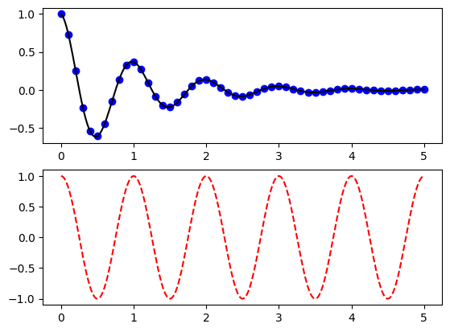

```python
plt.figure(1)
plt.subplot(2,1,1)
plt.plot(t1, f(t1), 'bo', t2, f(t2), 'k')

plt.subplot(2,1,2)
plt.plot(t2, np.cos(2*np.pi*t2), 'r--')
plt.show()
```

```python
# Simple data to display in various forms
x = np.linspace(0, 2 * np.pi, 400)
y = np.sin(x ** 2)
```

To create a **figure** with just **one subplot**, you can use the following:

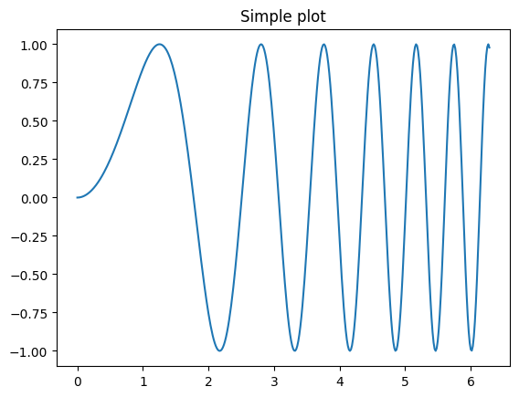

```python
f, ax = plt.subplots()
ax.plot(x, y)
ax.set_title('Simple plot')
plt.show()
```

To create a **figure** with **two subplots** in a 1-D array of axes:

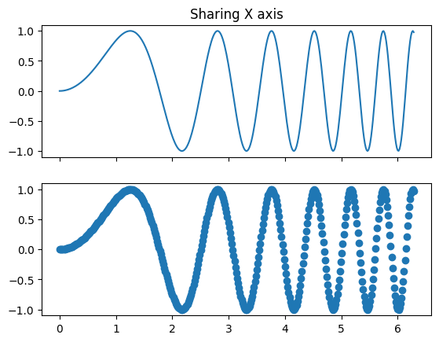

```python
f, axarr = plt.subplots(2, sharex=True)
axarr[0].plot(x, y)
axarr[0].set_title('Sharing X axis')
axarr[1].scatter(x, y)
plt.show()
```

Two subplots, unpack the axes array immediately

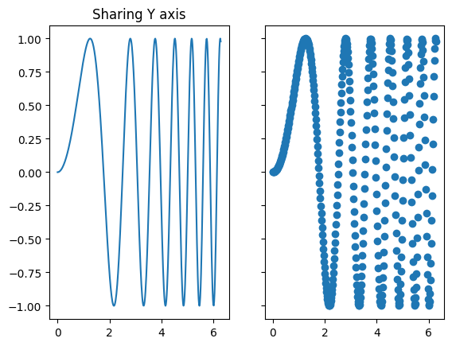

```python
f, (ax1, ax2) = plt.subplots(1, 2, sharey=True)
ax1.plot(x, y)
ax1.set_title('Sharing Y axis')
ax2.scatter(x, y)
```

To create a **figure** with **three subplots** sharing both **x** and **y** axes:

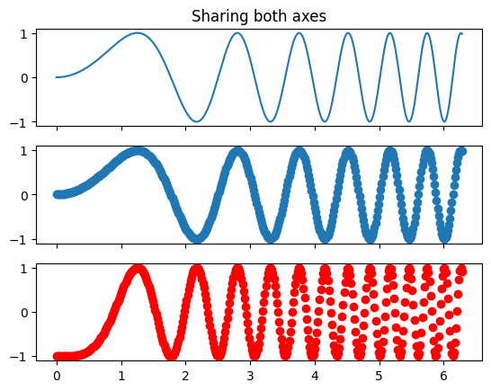

```python
f, (ax1, ax2, ax3) = plt.subplots(3, sharex=True, sharey=True)
ax1.plot(x, y)
ax1.set_title('Sharing both axes')
ax2.scatter(x, y)
ax3.scatter(x, 2 * y ** 2 - 1, color='r')
plt.show()
```

Fine-tune figure; make subplots close to each other and hide x ticks for all but bottom plot.

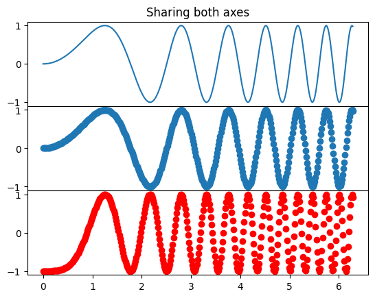

```python
f, (ax1, ax2, ax3) = plt.subplots(3, sharex=True, sharey=True)
ax1.plot(x, y)
ax1.set_title('Sharing both axes')
ax2.scatter(x, y)
ax3.scatter(x, 2 * y ** 2 - 1, color='r')

f.subplots_adjust(hspace=0)
plt.setp([a.get_xticklabels() for a in f.axes[:-1]], visible=False)
plt.show()
```

Row and column sharing:

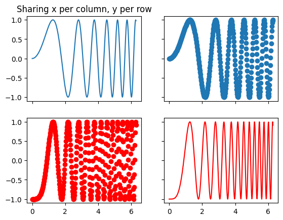

```python
f, ((ax1, ax2), (ax3, ax4)) = plt.subplots(2, 2, sharex='col', sharey='row')
ax1.plot(x, y)
ax1.set_title('Sharing x per column, y per row')
ax2.scatter(x, y)
ax3.scatter(x, 2 * y ** 2 - 1, color='r')
ax4.plot(x, 2 * y ** 2 - 1, color='r')
plt.show()
```

## 📌 Adding Text

```python
# Fixing random state for reproducibility
np.random.seed(618)

mu, sigma = 100, 15
x = mu + sigma * np.random.randn(10000)
```

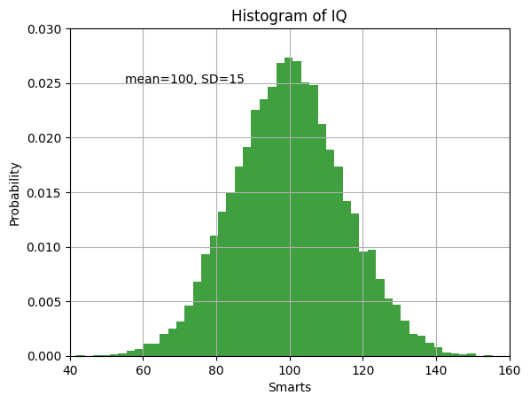

```python
# the histogram of the data
n, bins, patches = plt.hist(x, 50, density=True, facecolor='g', alpha=0.75)

plt.xlabel('Smarts')
plt.ylabel('Probability')
plt.title('Histogram of IQ')
plt.text(55, .025, f'mean={mu}, SD={sigma}')
plt.axis([40, 160, 0, 0.03])
plt.grid(True)
plt.show()
```

See also: 🔗 [Text Properties and Layout](https://matplotlib.org/users/text_props.html#text-properties) for customizing text in your plots, including font size, style, and positioning.

## 📌 Annotating Text

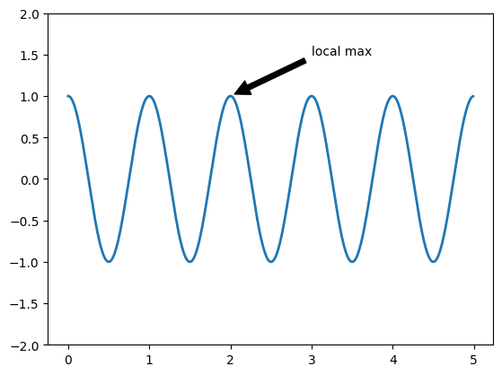

```python
ax = plt.subplot(111)

t = np.arange(0.0, 5.0, 0.01)
s = np.cos(2*np.pi*t)
line, = plt.plot(t, s, lw=2)

plt.annotate('local max',
             xy=(2, 1),
             xytext=(3, 1.5),
             arrowprops=dict(facecolor='black', shrink=0.05),
            )

plt.ylim(-2,2)
plt.show()
```

```python
menu = pd.read_csv('https://github.com/umsi-data-science/data/raw/main/menu.csv')
```

```python
menu.head()
```

|  | Category | Item | Serving Size | Calories | Calories from Fat | Total Fat | Total Fat (% Daily Value) | Saturated Fat | Saturated Fat (% Daily Value) | Trans Fat | ... | Carbohydrates | Carbohydrates (% Daily Value) | Dietary Fiber | Dietary Fiber (% Daily Value) | Sugars | Protein | Vitamin A (% Daily Value) | Vitamin C (% Daily Value) | Calcium (% Daily Value) | Iron (% Daily Value) |
| --- | --- | --- | --- | --- | --- | --- | --- | --- | --- | --- | --- | --- | --- | --- | --- | --- | --- | --- | --- | --- | --- |
| 0 | Breakfast | Egg McMuffin | 4.8 oz (136 g) | 300 | 120 | 13.0 | 20 | 5.0 | 25 | 0.0 | ... | 31 | 10 | 4 | 17 | 3 | 17 | 10 | 0 | 25 | 15 |
| 1 | Breakfast | Egg White Delight | 4.8 oz (135 g) | 250 | 70 | 8.0 | 12 | 3.0 | 15 | 0.0 | ... | 30 | 10 | 4 | 17 | 3 | 18 | 6 | 0 | 25 | 8 |
| 2 | Breakfast | Sausage McMuffin | 3.9 oz (111 g) | 370 | 200 | 23.0 | 35 | 8.0 | 42 | 0.0 | ... | 29 | 10 | 4 | 17 | 2 | 14 | 8 | 0 | 25 | 10 |
| 3 | Breakfast | Sausage McMuffin with Egg | 5.7 oz (161 g) | 450 | 250 | 28.0 | 43 | 10.0 | 52 | 0.0 | ... | 30 | 10 | 4 | 17 | 2 | 21 | 15 | 0 | 30 | 15 |
| 4 | Breakfast | Sausage McMuffin with Egg Whites | 5.7 oz (161 g) | 400 | 210 | 23.0 | 35 | 8.0 | 42 | 0.0 | ... | 30 | 10 | 4 | 17 | 2 | 21 | 6 | 0 | 25 | 10 |

5 rows × 24 columns

```python
menu.columns
```

```
Index(['Category', 'Item', 'Serving Size', 'Calories', 'Calories from Fat',
       'Total Fat', 'Total Fat (% Daily Value)', 'Saturated Fat',
       'Saturated Fat (% Daily Value)', 'Trans Fat', 'Cholesterol',
       'Cholesterol (% Daily Value)', 'Sodium', 'Sodium (% Daily Value)',
       'Carbohydrates', 'Carbohydrates (% Daily Value)', 'Dietary Fiber',
       'Dietary Fiber (% Daily Value)', 'Sugars', 'Protein',
       'Vitamin A (% Daily Value)', 'Vitamin C (% Daily Value)',
       'Calcium (% Daily Value)', 'Iron (% Daily Value)'],
      dtype='object')
```

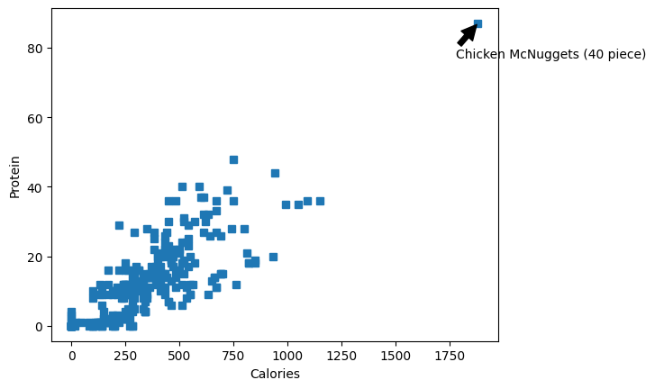

```python
max_cal_protein = menu[['Calories', 'Protein']].max()
# find outlier
max_cal_protein
max_item = menu['Item'][(menu['Calories'] == max_cal_protein['Calories']) & (menu['Protein'] == max_cal_protein['Protein'])].dropna()
max_item
# plot with callout
plt.plot(menu['Calories'], menu['Protein'], 's')
plt.xlabel('Calories')
plt.ylabel('Protein')
plt.annotate(max_item.values[0],
             xy=(max_cal_protein[0], max_cal_protein[1]),
             xytext=(max_cal_protein[0]-100, max_cal_protein[1]-10),
             arrowprops=dict(facecolor='black', shrink=0.05),
            )
```

## 📌 Using specific types of plots via pyplot

In addition to **scatterplots**, `pyplot` offers a variety of other plot types. You can access these through convenience functions such as:

- `scatter()` for scatter plots
- `hist()` for histograms
- `bar()` for vertical bar charts
- `barh()` for horizontal bar charts
- `pie()` for pie charts

...and many others! 🎨

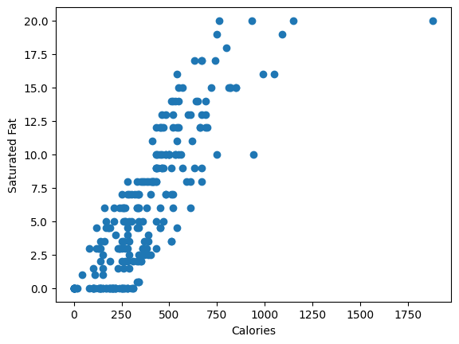

```python
plt.scatter(menu["Calories"], menu["Saturated Fat"])
plt.xlabel('Calories')
plt.ylabel('Saturated Fat')
plt.show()
```

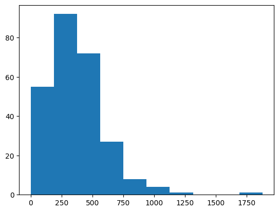

```python
plt.hist(menu['Calories'])
plt.show()
```

### 📝 **Challenge**:

Create a **histogram** for one of the continuous variables from the **McDonald's menu dataset**. 🍔🍟

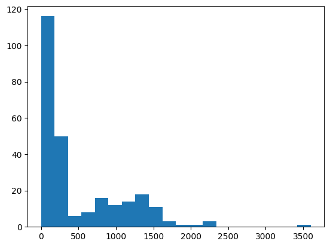

```python
# insert code here
max_salt = menu['Sodium'].max()
min_salt = menu['Sodium'].min()
plt.hist(menu['Sodium'], bins=20, range=(min_salt, max_salt))
```

## 📌 **Pandas and Matplotlib Integration**

Is it cumbersome? 🤔 Yes. But there's a **better way**! You can leverage the **Matplotlib integration** directly from **Pandas** for easier plotting:

```
# Example of using Pandas' built-in plotting capabilities
df['column_name'].plot(kind='hist')
```

```
matplotlib.axes._axes.Axes
```

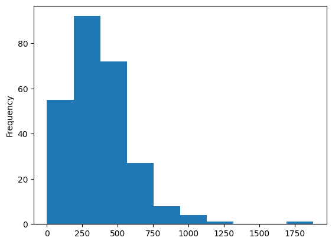

```python
f = menu['Calories'].plot(kind='hist')
type(f)
```

Here are the valid values for the `"kind"` parameter when using Pandas plotting:

- `'line'` : line plot (default)
- `'bar'` : vertical bar plot
- `'barh'` : horizontal bar plot
- `'hist'` : histogram
- `'box'` : boxplot
- `'kde'` : Kernel Density Estimation plot
- `'density'` : same as `'kde'`
- `'area'` : area plot
- `'pie'` : pie plot

## 📌 Bar plots with groupby()

```python
categories = menu.groupby('Category').size()
categories
```

```
Category
Beef & Pork           15
Beverages             27
Breakfast             42
Chicken & Fish        27
Coffee & Tea          95
Desserts               7
Salads                 6
Smoothies & Shakes    28
Snacks & Sides        13
dtype: int64
```

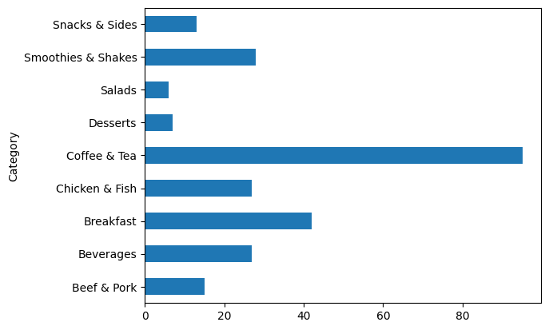

```python
categories.plot(kind='barh')
```

```python
categories_sorted = categories.sort_values(ascending=True)
```

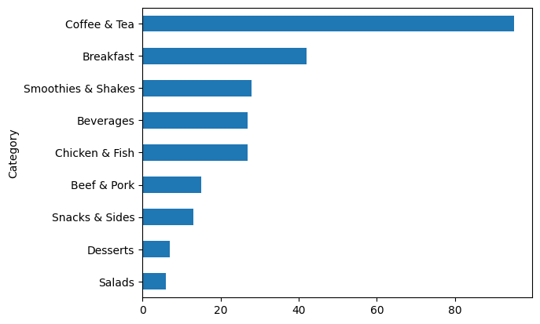

```python
categories_sorted.plot(kind='barh')
```

Let’s create a new column in the **menu DataFrame** called `"Sugary"`, where:

- The value is **1** if the `"Sugars"` content is greater than **20**
- Otherwise, the value is **0**

We'll use the `np.where()` function to do this. `np.where()` is a **vectorized version** of the ternary operator (i.e. `"if-then-else"`) and is highly efficient.

🔗 [np.where() documentation](https://docs.scipy.org/doc/numpy/reference/generated/numpy.where.html)  
🔗 It differs from the DataFrame method `.where()`: [DataFrame.where() documentation](https://pandas.pydata.org/pandas-docs/stable/reference/api/pandas.DataFrame.where.html).

```
# Example code to create the "Sugary" column
import numpy as np

menu['Sugary'] = np.where(menu['Sugars'] > 20, 1, 0)
```

```python
menu['Sugary'] =  np.where(menu['Sugars'] > 20, 1, 0)
```

```python
menu.sample(10)
```

|  | Category | Item | Serving Size | Calories | Calories from Fat | Total Fat | Total Fat (% Daily Value) | Saturated Fat | Saturated Fat (% Daily Value) | Trans Fat | ... | Carbohydrates (% Daily Value) | Dietary Fiber | Dietary Fiber (% Daily Value) | Sugars | Protein | Vitamin A (% Daily Value) | Vitamin C (% Daily Value) | Calcium (% Daily Value) | Iron (% Daily Value) | Sugary |
| --- | --- | --- | --- | --- | --- | --- | --- | --- | --- | --- | --- | --- | --- | --- | --- | --- | --- | --- | --- | --- | --- |
| 215 | Coffee & Tea | Iced Mocha with Nonfat Milk (Medium) | 16 fl oz cup | 290 | 45 | 5.0 | 8 | 3.5 | 17 | 0.0 | ... | 17 | 1 | 5 | 43 | 10 | 15 | 0 | 30 | 6 | 1 |
| 96 | Snacks & Sides | Small French Fries | 2.6 oz (75 g) | 230 | 100 | 11.0 | 17 | 1.5 | 8 | 0.0 | ... | 10 | 2 | 10 | 0 | 2 | 0 | 30 | 0 | 4 | 0 |
| 187 | Coffee & Tea | Nonfat Caramel Mocha (Small) | 12 fl oz cup | 250 | 30 | 3.5 | 5 | 2.0 | 10 | 0.0 | ... | 15 | 1 | 3 | 41 | 10 | 10 | 0 | 35 | 2 | 1 |
| 83 | Chicken & Fish | Filet-O-Fish | 5 oz (142 g) | 390 | 170 | 19.0 | 29 | 4.0 | 19 | 0.0 | ... | 13 | 2 | 7 | 5 | 15 | 2 | 0 | 15 | 10 | 0 |
| 17 | Breakfast | Southern Style Chicken Biscuit (Large Biscuit) | 5.5 oz (157 g) | 470 | 220 | 24.0 | 37 | 9.0 | 45 | 0.0 | ... | 15 | 3 | 11 | 4 | 17 | 4 | 2 | 8 | 15 | 0 |
| 68 | Chicken & Fish | Bacon Buffalo Ranch McChicken | 5.7 oz (161 g) | 430 | 190 | 21.0 | 32 | 5.0 | 25 | 0.0 | ... | 14 | 2 | 7 | 6 | 20 | 2 | 10 | 15 | 15 | 0 |
| 88 | Salads | Premium Southwest Salad with Crispy Chicken | 12.3 oz (348 g) | 450 | 190 | 22.0 | 33 | 4.5 | 22 | 0.0 | ... | 14 | 7 | 28 | 12 | 23 | 170 | 30 | 15 | 15 | 0 |
| 212 | Coffee & Tea | Iced Mocha (Medium) | 16 fl oz cup | 350 | 110 | 13.0 | 19 | 8.0 | 38 | 0.0 | ... | 17 | 1 | 5 | 43 | 9 | 10 | 0 | 30 | 6 | 1 |
| 30 | Breakfast | Big Breakfast with Egg Whites (Large Biscuit) | 10.1 oz (286 g) | 690 | 370 | 41.0 | 63 | 14.0 | 72 | 0.0 | ... | 18 | 4 | 17 | 4 | 26 | 4 | 2 | 10 | 15 | 0 |
| 119 | Beverages | Dr Pepper (Medium) | 21 fl oz cup | 190 | 0 | 0.0 | 0 | 0.0 | 0 | 0.0 | ... | 18 | 0 | 0 | 51 | 0 | 0 | 0 | 0 | 0 | 1 |

10 rows × 25 columns

## 📌 **Create a Stacked Bar Plot** 📊

To create a **stacked bar plot**, we can use a **2-level `groupby()`** followed by an **`unstack()`** to reshape the data. This approach is great for visualizing grouped data in a stacked format.

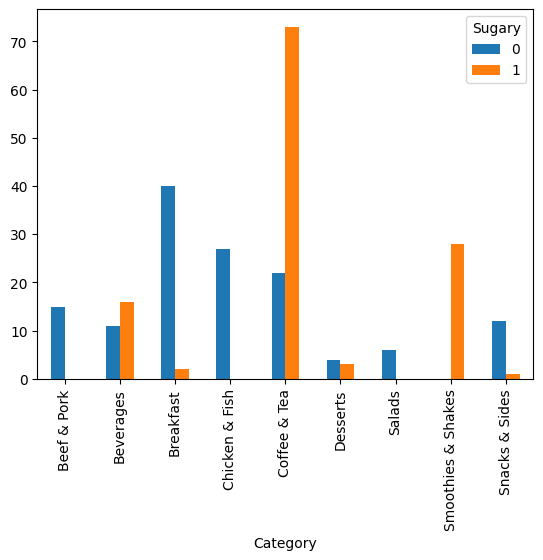

```python
menu.groupby(["Category", "Sugary"]).size().unstack().plot(kind="bar")
```

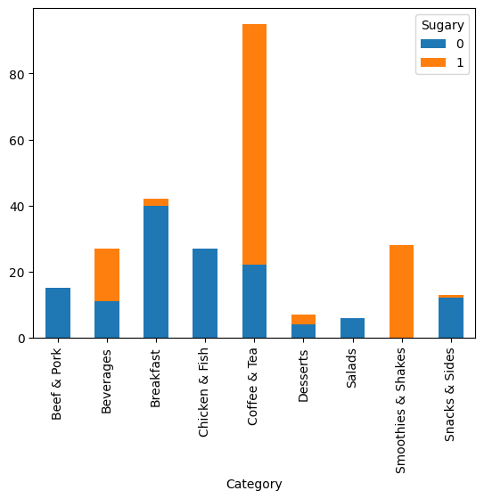

```python
menu.groupby(["Category", "Sugary"]).size().unstack().plot(kind="bar", stacked=True)
```

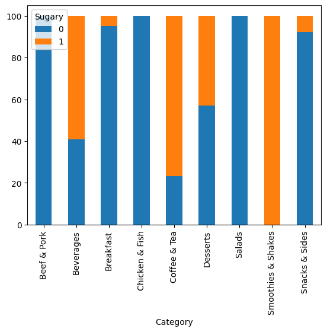

```python
menu.groupby(['Category', 'Sugary']).size().groupby(by='Category', group_keys=False).apply(
    lambda x: 100 * x / x.sum()
).unstack().plot(kind='bar', stacked=True)
```

### 📝 **Challenge**:

Repeat the steps above to generate **three bar plots** for any other continuous variable. Split the variable into **"high"** and **"low"** values, just as we did with `"Sugars"` earlier.

💡 Hint: You can use `np.where()` to create the "high" and "low" categories based on your chosen variable.

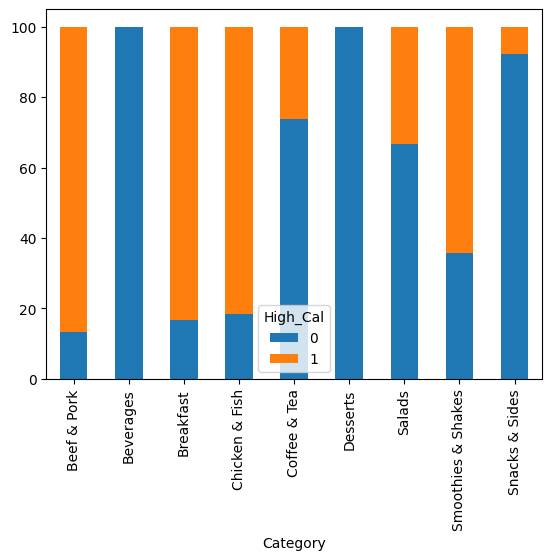

```python
mean_cals = menu['Calories'].mean()
menu['High_Cal'] = np.where(menu['Calories'] > mean_cals, 1, 0)
menu.groupby(['Category', 'High_Cal']).size().groupby(by='Category', group_keys=False).apply(
    lambda x: 100 * x / x.sum()
).unstack().plot(kind='bar', stacked=True)
```

```python
menu.describe().T
```

|  | count | mean | std | min | 25% | 50% | 75% | max |
| --- | --- | --- | --- | --- | --- | --- | --- | --- |
| Calories | 260.0 | 368.269231 | 240.269886 | 0.0 | 210.000 | 340.0 | 500.00 | 1880.0 |
| Calories from Fat | 260.0 | 127.096154 | 127.875914 | 0.0 | 20.000 | 100.0 | 200.00 | 1060.0 |
| Total Fat | 260.0 | 14.165385 | 14.205998 | 0.0 | 2.375 | 11.0 | 22.25 | 118.0 |
| Total Fat (% Daily Value) | 260.0 | 21.815385 | 21.885199 | 0.0 | 3.750 | 17.0 | 35.00 | 182.0 |
| Saturated Fat | 260.0 | 6.007692 | 5.321873 | 0.0 | 1.000 | 5.0 | 10.00 | 20.0 |
| Saturated Fat (% Daily Value) | 260.0 | 29.965385 | 26.639209 | 0.0 | 4.750 | 24.0 | 48.00 | 102.0 |
| Trans Fat | 260.0 | 0.203846 | 0.429133 | 0.0 | 0.000 | 0.0 | 0.00 | 2.5 |
| Cholesterol | 260.0 | 54.942308 | 87.269257 | 0.0 | 5.000 | 35.0 | 65.00 | 575.0 |
| Cholesterol (% Daily Value) | 260.0 | 18.392308 | 29.091653 | 0.0 | 2.000 | 11.0 | 21.25 | 192.0 |
| Sodium | 260.0 | 495.750000 | 577.026323 | 0.0 | 107.500 | 190.0 | 865.00 | 3600.0 |
| Sodium (% Daily Value) | 260.0 | 20.676923 | 24.034954 | 0.0 | 4.750 | 8.0 | 36.25 | 150.0 |
| Carbohydrates | 260.0 | 47.346154 | 28.252232 | 0.0 | 30.000 | 44.0 | 60.00 | 141.0 |
| Carbohydrates (% Daily Value) | 260.0 | 15.780769 | 9.419544 | 0.0 | 10.000 | 15.0 | 20.00 | 47.0 |
| Dietary Fiber | 260.0 | 1.630769 | 1.567717 | 0.0 | 0.000 | 1.0 | 3.00 | 7.0 |
| Dietary Fiber (% Daily Value) | 260.0 | 6.530769 | 6.307057 | 0.0 | 0.000 | 5.0 | 10.00 | 28.0 |
| Sugars | 260.0 | 29.423077 | 28.679797 | 0.0 | 5.750 | 17.5 | 48.00 | 128.0 |
| Protein | 260.0 | 13.338462 | 11.426146 | 0.0 | 4.000 | 12.0 | 19.00 | 87.0 |
| Vitamin A (% Daily Value) | 260.0 | 13.426923 | 24.366381 | 0.0 | 2.000 | 8.0 | 15.00 | 170.0 |
| Vitamin C (% Daily Value) | 260.0 | 8.534615 | 26.345542 | 0.0 | 0.000 | 0.0 | 4.00 | 240.0 |
| Calcium (% Daily Value) | 260.0 | 20.973077 | 17.019953 | 0.0 | 6.000 | 20.0 | 30.00 | 70.0 |
| Iron (% Daily Value) | 260.0 | 7.734615 | 8.723263 | 0.0 | 0.000 | 4.0 | 15.00 | 40.0 |
| Sugary | 260.0 | 0.473077 | 0.500238 | 0.0 | 0.000 | 0.0 | 1.00 | 1.0 |
| High_Cal | 260.0 | 0.446154 | 0.498051 | 0.0 | 0.000 | 0.0 | 1.00 | 1.0 |

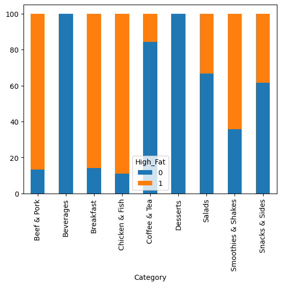

```python
mean_fat = menu['Total Fat'].mean()
menu['High_Fat'] = np.where(menu['Total Fat'] > mean_fat, 1, 0)
menu.groupby(['Category', 'High_Fat']).size().groupby(by='Category', group_keys=False).apply(
    lambda x: 100 * x / x.sum()
).unstack().plot(kind='bar', stacked=True)
```

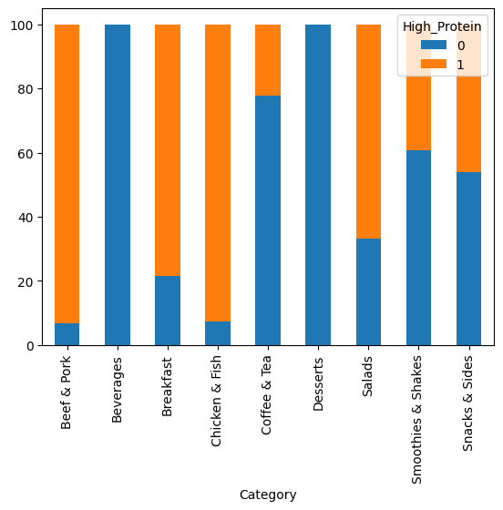

```python
mean_protein = menu['Protein'].mean()
menu['High_Protein'] = np.where(menu['Protein'] > mean_protein, 1, 0)
menu.groupby(['Category', 'High_Protein']).size().groupby(by='Category', group_keys=False).apply(
    lambda x: 100 * x / x.sum()
).unstack().plot(kind='bar', stacked=True)
```

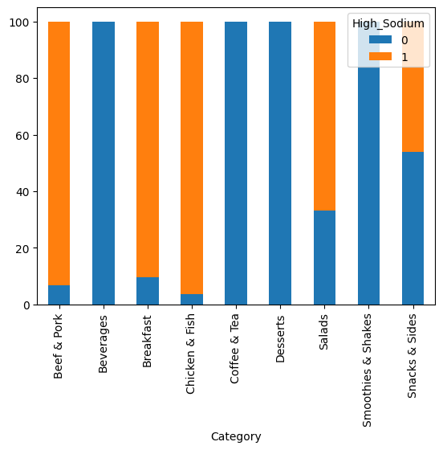

```python
# TODO: Sodium
mean_value = menu['Sodium'].mean()
menu['High_Sodium'] = np.where(menu['Sodium'] > mean_value, 1, 0)
menu.groupby(['Category', 'High_Sodium']).size().groupby(by='Category', group_keys=False).apply(
    lambda x: 100 * x / x.sum()
).unstack().plot(kind='bar', stacked=True)
```